# Machine Learning Harvard Capstone Movie Lens Project R Notebook

### Machine Learning Harvard Capstone Movie Lens Project R Notebook

June 2019

This is my Move Lens project for the Capstone Course in the HarvardX Data Science Certificate Program.

Student: Philip Brown email: Phil@pjb3.com github: https://github.com/pjbMit

The project was created in the RStudio environment using Rstudio Version 1.1.442 on a Macintosh; Intel Mac OS X 10_14_5

R version 3.5.1 (2018-07-02)  
nickname Feather Spray

See the README.Rmd or README.html files for more information on the environment and setup.

For questions, email me: pjbMit@pjb3.com , and I’ll gladly respond promptly.

1. Develop your algorithm using the edx set.
2. For a final test of your algorithm, predict movie ratings in the validation set as if they were unknown.
3. RMSE will be used to evaluate how close your predictions are to the true values in the validation set.

## Set up.

Data is downloaded from https://grouplens.org/datasets/movielens/10m/

Data setup

I needed to make two basic changes: First) I needed to use a different repository to load the libraries, because repo specified didn’t work on my mac. Second) This R Code crashed RStudio repeatedly, so I created a function and added code to save objects as files, so that I could save intermediate results into a file, and then reload them if and as necessary if R crashed. With these two work-arounds, I was able to load and process all of the data without incident.

```r
repo
```

```
[1] "https://cran.revolutionanalytics.com/"
```

## Note: Because I had to run the code line-by-line, the output doesn’t show up in the output file produced by the RMD.

## Please don’t penalize me for this side effect of RSTUDIO crashing when I ran the whole script at once.

#### OUT LINE

General approach:

For many approaches, I will first try on a very small data set, just to get the code working, the re-run on a medium sized data set, and then when I am satisfied, run on the full edx training set.

Similarly, initially I will NOT do full cross-validation, but once I have code working, then I will.

SET UP libraries and enable turn multi-core processing for some of operations used by the caret package.

Now the edx object and the validation object are both saved on the file system, so as a short-cut I can reload those objects from disk to run my code, rather than having to download and process the raw data multiple times during development.

```r
#Load libraries, installing as necessary
if(!require(tidyverse)) install.packages("tidyverse", repos = repos)
if(!require(caret)) install.packages("caret", repos = repos)
if(!require(mlbench)) install.packages("mlbench", repos = repo)
# Multicore processing package for caret.
if(!require(doMC)) install.packages("doMC", repos = repos)
registerDoMC(cores=8)
#For ctree model.  See https://rpubs.com/chengjiun/52658
if(!require(party)) install.packages("party", repos = repos)
#Function to load the edx object from a saved file.
#This allows faster re-runs of the code, by avoiding downloading and re-processing
#the data through each development iteration.
restoreEdx <- function(loadFromFile){
    if(loadFromFile){
        edxFile <- "~/edxFile.rds"
        edx <- readRDS(edxFile)
    }
    edx
}
#Function to load the validation object from a saved file.
#This allows faster re-runs of the code, by avoiding downloading and re-processing
#the data through each development iteration.
restoreValidation <- function(loadFromFile){
    if(loadFromFile){
        validationFile <- "~/validationFile.rds"
        validation <- readRDS(validationFile)
    }
    validation
}
# Function to get the repository to use
# Needed because on my Mac, the standard CRAN repository gave me errors.
getRepos <- function() {
    isMac <- TRUE
    #isMac <- FALSE  ##Set to false if you are NOT running on a Mac.
    ifelse(isMac,repo <- "https://cran.revolutionanalytics.com/" , repo <- "http://cran.us.r-project.org")
    }
repos <- getRepos() #Use a differnt repository for R packages if on the Mac
#Now define some utility functions and functions used to preProcess the data.
# Function that calls createDataPartition to return a subset of the data frame.
# Created so that I can develop the code on a subset of the training data,
# so that the code will run faster during development
getSubset <- function(df,y,percent){
   #rows <- length(res[,1])
   # n <- as.integer(rows * percent)
   set.seed(1967) # For repeatability
   subset_index <- createDataPartition(y = y, times = 1, p = percent, list = FALSE)
   res <- df[subset_index,]
   res
}
# Function to process the data and return only the unique generes.
# Pares out the genere separator "|"
getAllGenres <- function(edxData) {
    edxData %>% separate_rows(genres, sep = "\\|") %>%
    group_by(genres) %>%
    summarize(count = n()) %>%
    arrange(desc(count)) %>%
    select(genres)
}
#Function extractGenresData is used to convert each genre into its own column
#The function accepts then name of a single movie genere, and returns a vector of 1's and 0's
#indicating whether or not that genere name is part of the genres string from that movie
extractGenresData <- function(oneGenre,genresByMovie){
    #genresByMovie %>% filter( grepl(oneGenre, genresByMovie$genres, fixed = TRUE))  # %>% count()
    res <- grepl(oneGenre, genresByMovie$genres, fixed = TRUE)
    sapply(res, as.numeric) ## Convert all logical values to numeric
}
## Function myPreProcess preprocesses the data.
## It Accepts the training data frame, and returns a new data frame
## containing the preProcessed data
myPreProcess <- function (data) {
    allGenres <- getAllGenres(data)   # gets all generes
    allGenresStr <- allGenres$genres  # A vector with one entry for each unique genere
    rm(allGenres)
    genresByMovie <- data %>% select(genres) # string containing multiple generes with | separator
    oneRow <- extractGenresData("Comedy",genresByMovie)  #Get one row, just to test "extracting" one genre
    glimpse(oneRow)
    # For each movie, Extract genres into T/F columns
    genreDf <- as_tibble(sapply(allGenresStr,extractGenresData,genresByMovie))
    rm(allGenresStr)

    dim(genreDf)  #Just to see the value
    #Now convert certain fields to factors, since they are intended as labels, and not meaningful numeric values.
    factors <- data  %>%
    transmute(userId=userId,
              movieId=movieId,
              titleId=as.factor(title),
              genres=as.factor(genres))
    dim(factors) #just to see the value

    # Get the movie data with factors and genres,
    # and add the rating, which is the random variable we want to predict, as the last column
    moviesWithGenre <- cbind(factors,genreDf,tibble(test=data$test)) %>%
                        mutate(rating=data$rating)
    moviesWithGenre #And return the now preProcessed data frame that is the result.
}
#
# Function getData is used to run the code on a subset of the data
# during development, so that the code runs faster.
# This function will either return the data pased,
# or  a subset of the data based on the value of returnSubSet  second parameter
#
getData <- function (data,returnSubSet) {
 myData <- data
 if(returnSubSet)
   { #Only use a Subset if in development
    #percent <- 0.001
    percent <- 0.01
    dataSubset <- getSubset(data,edx$rating,percent)
    myData <- dataSubset

    }
myData  #Return the data
}
```

The code below will load the edx and validation data from local files, after it has been downloaded, processed and saved per the instructions provided. You can re-run this chunk of code to reload the data, rather than download and process it again.

```r
loadFromFile <- FALSE
loadFromFile <- TRUE  ## Comment out this line if we don't want to reload the ojbects from files
# load the data from the saved file
edx <- restoreEdx(loadFromFile)
validation <- restoreValidation(loadFromFile)
```

PreProcess the data. During development, only preprocess a subset of the data so that code runs quickly. Run on the full set of data once development is completed, and it works.

```r
##Preprocess and get either the training data, or a subset it, depending on the value of inDevlopment.
# To make computations faster,
# only use a small subset of the training data for now.
# Later, re-run the code using the full training set once everything works.
inDevelopment <- FALSE # TRUE/FALSE value to only use a subset of data during development
inDevelopment <- TRUE  # To use the full training set, comment out this line and re-run the code.

data <- getData(edx,inDevelopment)  # Get the training data, or a subset of it.
glimpse(data)
```

```
Observations: 90,002
Variables: 6
$ userId    <int> 1, 5, 8, 8, 8, 8, 8, 8, 8, 8, 8, 9, 11, 12, 13, 13, 16, 16, 18, 18, 18, 19, 23, 23, 23, 24, 30,…
$ movieId   <dbl> 362, 903, 540, 547, 799, 1552, 3254, 4701, 5574, 6564, 8169, 1288, 2091, 2369, 71, 3408, 1129, …
$ rating    <dbl> 5.0, 4.0, 2.5, 3.0, 4.5, 2.0, 4.0, 3.0, 4.0, 3.0, 3.5, 5.0, 4.0, 3.0, 2.0, 3.0, 3.0, 3.0, 2.0, …
$ timestamp <int> 838984885, 857912792, 1115860187, 1116548236, 1111546100, 1115858322, 1116547021, 1111624117, 1…
$ title     <chr> "Jungle Book, The (1994)", "Vertigo (1958)", "Sliver (1993)", "Surviving the Game (1994)", "Fri…
$ genres    <chr> "Adventure|Children|Romance", "Drama|Mystery|Romance|Thriller", "Thriller", "Action|Adventure|T…
```

```r
d1 <- data %>% mutate(test=FALSE)
d2 <- validation %>% mutate(test=TRUE)
movieDataWithGenre <- myPreProcess(rbind(d1,d2)) # Preprocess and get subsets of the data
```

```
 num [1:1090001] 0 0 0 0 1 0 1 1 0 1 ...
```

```r
glimpse(movieDataWithGenre)
```

```
Observations: 1,090,001
Variables: 25
$ userId      <int> 1, 5, 8, 8, 8, 8, 8, 8, 8, 8, 8, 9, 11, 12, 13, 13, 16, 16, 18, 18, 18, 19, 23, 23, 23, 24, 3…
$ movieId     <dbl> 362, 903, 540, 547, 799, 1552, 3254, 4701, 5574, 6564, 8169, 1288, 2091, 2369, 71, 3408, 1129…
$ titleId     <fct> "Jungle Book, The (1994)", "Vertigo (1958)", "Sliver (1993)", "Surviving the Game (1994)", "F…
$ genres      <fct> Adventure|Children|Romance, Drama|Mystery|Romance|Thriller, Thriller, Action|Adventure|Thrill…
$ Drama       <dbl> 0, 1, 0, 0, 0, 0, 0, 0, 0, 0, 0, 0, 0, 1, 0, 1, 0, 0, 0, 1, 0, 0, 0, 1, 0, 0, 0, 1, 1, 0, 1, …
$ Comedy      <dbl> 0, 0, 0, 0, 1, 0, 1, 1, 0, 1, 1, 1, 0, 1, 0, 0, 0, 0, 1, 0, 1, 1, 0, 0, 0, 0, 0, 0, 1, 0, 1, …
$ Action      <dbl> 0, 0, 0, 1, 0, 1, 0, 1, 1, 1, 0, 0, 0, 0, 1, 0, 1, 0, 0, 1, 0, 0, 1, 0, 1, 1, 0, 0, 0, 1, 0, …
$ Thriller    <dbl> 0, 1, 1, 1, 1, 1, 0, 0, 0, 1, 0, 0, 0, 0, 0, 0, 1, 0, 0, 0, 0, 0, 1, 1, 0, 1, 1, 0, 0, 0, 0, …
$ Adventure   <dbl> 1, 0, 0, 1, 0, 1, 0, 0, 0, 1, 0, 0, 0, 0, 0, 0, 1, 1, 0, 0, 0, 0, 1, 0, 1, 1, 0, 1, 0, 0, 0, …
$ Romance     <dbl> 1, 1, 0, 0, 0, 0, 0, 0, 0, 1, 0, 0, 0, 1, 0, 0, 0, 0, 0, 0, 0, 0, 0, 1, 0, 0, 0, 0, 1, 0, 1, …
$ `Sci-Fi`    <dbl> 0, 0, 0, 0, 0, 0, 0, 0, 0, 0, 1, 0, 1, 0, 0, 0, 1, 0, 0, 0, 0, 0, 0, 0, 1, 0, 0, 0, 0, 0, 0, …
$ Crime       <dbl> 0, 0, 0, 0, 0, 0, 0, 0, 1, 0, 0, 0, 0, 0, 0, 0, 0, 0, 0, 0, 0, 0, 0, 1, 0, 0, 1, 0, 0, 0, 0, …
$ Fantasy     <dbl> 0, 0, 0, 0, 0, 0, 0, 0, 0, 0, 1, 0, 0, 0, 0, 0, 0, 1, 1, 0, 0, 0, 0, 0, 0, 0, 0, 0, 0, 0, 0, …
$ Children    <dbl> 1, 0, 0, 0, 0, 0, 0, 0, 0, 0, 1, 0, 1, 0, 0, 0, 0, 1, 0, 0, 0, 0, 0, 0, 0, 0, 0, 0, 0, 0, 0, …
$ Horror      <dbl> 0, 0, 0, 0, 1, 0, 0, 0, 0, 0, 0, 0, 0, 0, 0, 0, 0, 0, 0, 0, 0, 0, 0, 0, 0, 0, 1, 0, 0, 0, 0, …
$ Mystery     <dbl> 0, 1, 0, 0, 0, 0, 0, 0, 0, 0, 0, 0, 0, 0, 0, 0, 0, 0, 0, 0, 0, 0, 0, 0, 0, 0, 1, 0, 0, 0, 0, …
$ War         <dbl> 0, 0, 0, 0, 0, 0, 0, 0, 0, 0, 0, 0, 0, 0, 0, 0, 0, 0, 0, 0, 0, 0, 0, 0, 1, 0, 0, 0, 0, 0, 0, …
$ Animation   <dbl> 0, 0, 0, 0, 0, 0, 0, 0, 0, 0, 0, 0, 0, 0, 0, 0, 0, 1, 0, 0, 0, 0, 0, 0, 0, 0, 0, 0, 0, 0, 0, …
$ Musical     <dbl> 0, 0, 0, 0, 0, 0, 0, 0, 0, 0, 0, 1, 0, 0, 0, 0, 0, 0, 0, 0, 0, 0, 0, 0, 0, 0, 0, 0, 0, 0, 0, …
$ Western     <dbl> 0, 0, 0, 0, 0, 0, 0, 0, 0, 0, 0, 0, 0, 0, 0, 0, 0, 0, 0, 0, 0, 0, 0, 0, 0, 0, 0, 0, 0, 0, 0, …
$ `Film-Noir` <dbl> 0, 0, 0, 0, 0, 0, 0, 0, 0, 0, 0, 0, 0, 0, 0, 0, 0, 0, 0, 0, 0, 0, 0, 0, 0, 0, 0, 0, 0, 0, 0, …
$ Documentary <dbl> 0, 0, 0, 0, 0, 0, 0, 0, 0, 0, 0, 0, 0, 0, 0, 0, 0, 0, 0, 0, 0, 0, 0, 0, 0, 0, 0, 0, 0, 0, 0, …
$ IMAX        <dbl> 0, 0, 0, 0, 0, 0, 0, 0, 0, 0, 0, 0, 0, 0, 0, 0, 0, 0, 0, 0, 0, 0, 0, 0, 0, 0, 0, 0, 0, 0, 0, …
$ test        <lgl> FALSE, FALSE, FALSE, FALSE, FALSE, FALSE, FALSE, FALSE, FALSE, FALSE, FALSE, FALSE, FALSE, FA…
$ rating      <dbl> 5.0, 4.0, 2.5, 3.0, 4.5, 2.0, 4.0, 3.0, 4.0, 3.0, 3.5, 5.0, 4.0, 3.0, 2.0, 3.0, 3.0, 3.0, 2.0…
```

```r
myTrain <- movieDataWithGenre %>% filter(test==FALSE) %>% select (-test,-genres)
myTest  <- movieDataWithGenre %>% filter(test==TRUE) %>% select (-test)
rm(d1,d2,movieDataWithGenre)
```

First look at the most naive approach… and notice that 3.51 is the mu_hat that has the lowest RMSE.

```r
# Using model Y_u_i = U + E_u_i
mu_hat <- mean(myTrain$rating)
mu_hat
```

```
[1] 3.512977
```

```r
#Function calculates RMSE, substituting zero as the error for NA rows
myRMSE <- function(true_ratings, predicted_ratings){
    diff <- true_ratings - predicted_ratings
    #Replace NA with zero
    diff[is.na(diff)]<-0
    sqrt(mean((diff)^2))
  }
naive_rmse <- myRMSE(myTest$rating, mu_hat)
#Now create a results table, so that we can compare different approaches
rmse_results <- tibble(method = "Just the average", RMSE = naive_rmse)
rmse_results
```

| method | RMSE |
| --- | --- |
| Just the average | 1.061202 |

```r
# See how any other value increase or RMSE
#errors<-sapply(seq(2.5,4,.01),function(mu_hat) RMSE(myTest$rating, mu_hat))
#plot(seq(2.5,4,.01),errors)
mu <- mean(myTrain$rating)
movie_avgs <- myTrain %>%
  group_by(movieId) %>%
  summarize(b_i = mean(rating - mu))
#movie_avgs %>% qplot(b_i, geom ="histogram", bins = 10, data = ., color = I("black"))
predicted_ratings <- mu + myTest %>%
  left_join(movie_avgs, by='movieId') %>%
  pull(b_i)
predicted_ratings[is.na(predicted_ratings)]<-mu  ## use the mu_hat for any NA values
#predicted_ratings <- tibble(rating=predicted_ratings) ## Get predicted ratings
model_1_rmse <- myRMSE(predicted_ratings, myTest$rating)
rmse_results <- bind_rows(rmse_results,
                          tibble(method="Movie Effect Model",
                                     RMSE = model_1_rmse))
rmse_results
```

| method | RMSE |
| --- | --- |
| Just the average | 1.0612021 |
| Movie Effect Model | 0.9815412 |

```r
user_avgs <- myTrain %>%
  left_join(movie_avgs, by='movieId') %>%
  group_by(userId) %>%
  summarize(b_u = mean(rating - mu - b_i))
sum(user_avgs$b_u[is.na(user_avgs$b_u)])  #Check for NA's
```

```
[1] 0
```

```r
predicted_ratings <- myTest %>%
  left_join(movie_avgs, by='movieId') %>%
  left_join(user_avgs, by='userId') %>%
  mutate(pred = mu + b_i + b_u) %>%
  pull(pred)
model_2_rmse <- myRMSE(predicted_ratings, myTest$rating)
rmse_results <- bind_rows(rmse_results,
                          tibble(method="Movie + User Effects Model",
                                     RMSE = model_2_rmse))
rmse_results
```

| method | RMSE |
| --- | --- |
| Just the average | 1.0612021 |
| Movie Effect Model | 0.9815412 |
| Movie + User Effects Model | 0.9286946 |

```r
#34.11.2 Connection to SVD and PCA
# https://rafalab.github.io/dsbook/large-datasets.html#recommendation-systems
###
###  TODO -- Add regularization
###
###  And then do PCA to figure out genre's that have an impact
###  And then add genre effect
```

Now We’ll add regularization

```r
lambda <- 3
mu <- mean(myTrain$rating)
movie_reg_avgs <- myTrain %>%
  group_by(movieId) %>%
  summarize(b_i = sum(rating - mu)/(n()+lambda), n_i = n())
predicted_ratings <- myTest %>%
  left_join(movie_reg_avgs, by = "movieId") %>%
  mutate(pred = mu + b_i) %>%
  pull(pred)
model_3_rmse <- myRMSE(predicted_ratings, myTest$rating)
rmse_results <- bind_rows(rmse_results,
                          tibble(method="Regularized Movie Effect Model",
                                     RMSE = model_3_rmse))
rmse_results
```

| method | RMSE |
| --- | --- |
| Just the average | 1.0612021 |
| Movie Effect Model | 0.9815412 |
| Movie + User Effects Model | 0.9286946 |
| Regularized Movie Effect Model | 0.9541931 |

Now we will tune the parameter lambda.

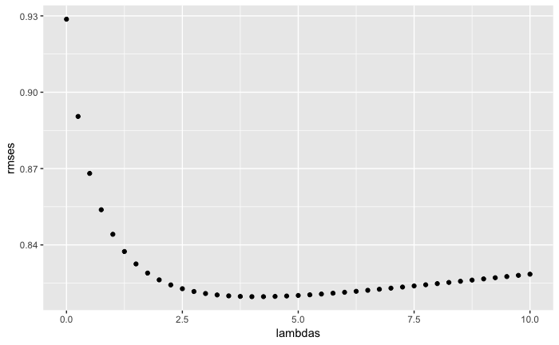

```r
# The estimates that minimize this can be found similarly to what we did above.
# Here we use cross-validation to pick a  λ
lambdas <- seq(0, 10, 0.25)
rmses <- sapply(lambdas, function(l){
  mu <- mean(myTrain$rating)

  b_i <- myTrain %>%
    group_by(movieId) %>%
    summarize(b_i = sum(rating - mu)/(n()+l))

  b_u <- myTrain %>%
    left_join(b_i, by="movieId") %>%
    group_by(userId) %>%
    summarize(b_u = sum(rating - b_i - mu)/(n()+l))
  predicted_ratings <-
    myTest %>%
    left_join(b_i, by = "movieId") %>%
    left_join(b_u, by = "userId") %>%
    mutate(pred = mu + b_i + b_u) %>%
    pull(pred)

    return(myRMSE(predicted_ratings, myTest$rating))
})
qplot(lambdas, rmses)
```

```r
lambda <- lambdas[which.min(rmses)]
lambda
```

```
[1] 4
```

```r
rmse_results <- bind_rows(rmse_results,
                          tibble(method="Regularized Movie + User Effect Model",
                                     RMSE = min(rmses)))
rmse_results %>% knitr::kable()
```

```
|method                                |      RMSE|
|:-------------------------------------|---------:|
|Just the average                      | 1.0612021|
|Movie Effect Model                    | 0.9815412|
|Movie + User Effects Model            | 0.9286946|
|Regularized Movie Effect Model        | 0.9541931|
|Regularized Movie + User Effect Model | 0.8196661|
```

```r
#free memory
rm(data,edx,validation,predicted_ratings,user_avgs,movie_avgs,movie_reg_avgs)
```

```r
library(matrixStats)
library(tidyverse)
x<-as.matrix(myTrain[5:23])
glimpse(x)
```

```
 num [1:90002, 1:19] 0 0 0 0 1 0 1 1 0 1 ...
 - attr(*, "dimnames")=List of 2
  ..$ : NULL
  ..$ : chr [1:19] "Comedy" "Action" "Thriller" "Adventure" ...
```

```r
sds <- colSds(x, na.rm = TRUE)
o <- order(sds, decreasing = TRUE)[1:19]
dim(x)
```

```
[1] 90002    19
```

```r
x2 <- as.matrix(getSubset(x[,o],myTrain$rating,0.02))
dim(x2)
```

```
[1] 1802   19
```

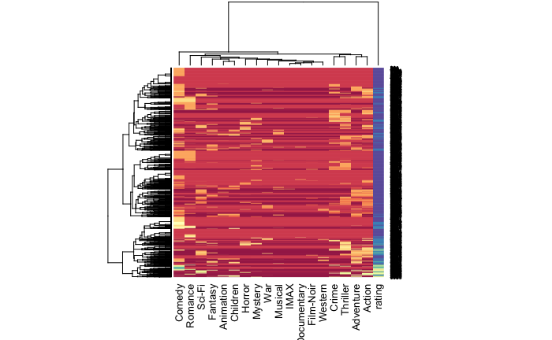

```r
heatmap(x2[,o], col = RColorBrewer::brewer.pal(11, "Spectral"))
```

```r
apply(x2[,o],MARGIN=2,mean)
```

```
       IMAX      rating      Comedy      Action    Thriller   Adventure       Crime     Romance      Sci-Fi
0.001109878 3.520532741 0.407325194 0.283018868 0.243063263 0.211986681 0.158712542 0.182019978 0.140399556
    Fantasy    Children      Horror     Mystery         War   Animation     Musical     Western   Film-Noir
0.105993341 0.074361820 0.076581576 0.064927858 0.047724750 0.049944506 0.038290788 0.019977802 0.010543840
Documentary
0.007214206
```

```r
top <- x[1,1:5]
cols <- names(top)
```

Now we’re going to try training on a subset of the data, using a handful of the columns.

```r
train_small <- myTrain %>%
  group_by(movieId) %>%
  filter(n() >= 1 | movieId == 3252) %>% ungroup() %>%
  group_by(userId) %>%
  filter(n() >= 10) %>% ungroup()
y <- train_small %>%
  mutate(userId = as.numeric(userId),movieId = as.numeric(movieId)) %>%
  select(userId, movieId, rating) %>%
  spread(movieId, rating) %>%
  as.matrix()
dim(y)
```

```
[1]  927 4669
```

```r
glimpse(y)
```

```
 num [1:927, 1:4669] 144 182 212 215 276 289 426 513 533 867 ...
 - attr(*, "dimnames")=List of 2
  ..$ : NULL
  ..$ : chr [1:4669] "userId" "1" "2" "3" ...
```

```r
y[is.na(y)] <- 0 #Replace NA with zero
#y <- matrix(sapply(y,as.numeric),2) #And make values numeric
# Add row names
rownames(y)<- y[,1]
y <- y[,-1]
#Add col names
movie_titles <- myTrain %>%
  select(movieId, titleId) %>%
  distinct()
colnames(y) <- with(movie_titles, titleId[match(colnames(y), movieId)])
colnames(y)
```

```
   [1] "Toy Story (1995)"
   [2] "Jumanji (1995)"
   [3] "Grumpier Old Men (1995)"
   [4] "Waiting to Exhale (1995)"
   [5] "Father of the Bride Part II (1995)"
   [6] "Heat (1995)"
   [7] "Sabrina (1995)"
   [8] "Tom and Huck (1995)"
   [9] "Sudden Death (1995)"
  [10] "GoldenEye (1995)"
  [11] "American President, The (1995)"
  [12] "Dracula: Dead and Loving It (1995)"
  [13] "Nixon (1995)"
  [14] "Cutthroat Island (1995)"
  [15] "Casino (1995)"
```

[output cut: 986 more lines]

```r
rownames(y)
```

```
  [1] "144"   "182"   "212"   "215"   "276"   "289"   "426"   "513"   "533"   "867"   "1224"  "1302"  "1377"
 [14] "1408"  "1724"  "1786"  "1854"  "1860"  "1918"  "2385"  "2515"  "2596"  "2765"  "2852"  "3022"  "3041"
 [27] "3089"  "3149"  "3171"  "3174"  "3220"  "3301"  "3350"  "3476"  "3635"  "3646"  "3793"  "3795"  "3810"
 [40] "3817"  "4129"  "4229"  "4368"  "4513"  "4523"  "4538"  "4598"  "4783"  "5039"  "5085"  "5129"  "5134"
 [53] "5168"  "5262"  "5275"  "5425"  "5578"  "5678"  "5711"  "5779"  "5794"  "5829"  "5917"  "5939"  "5955"
 [66] "6018"  "6393"  "6443"  "6477"  "6508"  "6610"  "6678"  "6757"  "6845"  "6948"  "6971"  "6992"  "7061"
 [79] "7127"  "7145"  "7181"  "7304"  "7315"  "7380"  "7461"  "7587"  "7612"  "7707"  "7711"  "7774"  "7795"
 [92] "7849"  "8031"  "8114"  "8152"  "8188"  "8265"  "8275"  "8352"  "8604"  "8651"  "8676"  "8683"  "8740"
[105] "8811"  "8849"  "8867"  "8892"  "8930"  "8960"  "9060"  "9117"  "9139"  "9181"  "9355"  "9462"  "9522"
[118] "9531"  "9554"  "9595"  "9719"  "9809"  "9844"  "9902"  "9922"  "9939"  "10036" "10051" "10127" "10368"
[131] "10516" "10669" "10680" "10759" "10791" "10858" "10963" "11117" "11244" "11342" "11434" "11514" "11576"
[144] "11606" "11638" "11681" "11760" "11898" "12012" "12013" "12069" "12089" "12248" "12253" "12296" "12309"
[157] "12367" "12394" "12561" "12644" "12660" "12752" "12759" "12791" "12861" "12904" "12957" "13122" "13383"
[170] "13614" "13635" "13669" "13716" "13841" "13867" "13876" "13900" "13912" "14068" "14076" "14094" "14134"
[183] "14145" "14390" "14463" "14474" "14578" "14653" "14916" "14921" "15061" "15224" "15283" "15288" "15311"
```

[output cut: 57 more lines]

```r
#and convert them to residuals by removing the column and row effects:
y <- sweep(y, 2, colMeans(y, na.rm=TRUE))
y <- sweep(y, 1, rowMeans(y, na.rm=TRUE))
sum(is.na(y))
```

```
[1] 0
```

```r
dim(y)
```

```
[1]  927 4668
```

```r
pca <- prcomp(y)
#cor(x, use="pairwise.complete")
#The  q  vectors are called the principal components and they are stored in this matrix:
dim(pca$rotation)
```

```
[1] 4668  927
```

```r
#While the  p, or the user effects, are here:
dim(pca$x)
```

```
[1] 927 927
```

```r
pcs <- data.frame(pca$rotation, name = str_trunc(colnames(y), 30))
pcs %>% select(name, PC1) %>% arrange(PC1) %>% slice(1:20)
```

```
                             name         PC1
1    It's a Wonderful Life (1946) -0.05098781
2      Father of the Bride (1950) -0.04441821
3  All About My Mother (Todo s... -0.04265658
4               Spider-Man (2002) -0.03980173
5  After Life (Wandafuru raifu... -0.03666322
6          Last Waltz, The (1978) -0.03666322
7  Muppets Take Manhattan, The... -0.03599804
8            Lady Eve, The (1941) -0.03557379
9             Lost Horizon (1937) -0.03449810
10      I'm All Right Jack (1959) -0.03410316
11 Garden of the Finzi-Contini... -0.03389443
12               Viridiana (1961) -0.03307909
13      Secret Garden, The (1993) -0.03176270
14             Real Genius (1985) -0.03073115
15          Pink Flamingos (1972) -0.03050783
16 My Kid Could Paint That (2007) -0.03013241
17        Apple, The (Sib) (1998) -0.02949496
18        Pajama Game, The (1957) -0.02949496
19           Hester Street (1975) -0.02949496
20           I'm Not There (2007) -0.02949496
```

```r
pcs %>% select(name, PC1) %>% arrange(desc(PC1)) %>% slice(1:20)
```

```
                             name       PC1
1        Great Escape, The (1963) 0.2328246
2  Guess Who's Coming to Dinne... 0.2137908
3       American History X (1998) 0.2016578
4             River's Edge (1986) 0.1908316
5  Bang, Bang, You're Dead (2002) 0.1701428
6               Relic, The (1997) 0.1676678
7             Shooter, The (1997) 0.1676678
8            Haunting, The (1963) 0.1676678
9              Hidden, The (1987) 0.1676678
10                 Bullitt (1968) 0.1567669
11            Stone Reader (2002) 0.1508188
12        Perfect World, A (1993) 0.1491881
13                Oh, God! (1977) 0.1449762
14             Deep Impact (1998) 0.1438842
15 Incredible Shrinking Man, T... 0.1437543
16          Altered States (1980) 0.1430091
17             I Am Legend (2007) 0.1407326
18   In the Valley of Elah (2007) 0.1391108
19   Sidewalks of New York (2001) 0.1385662
20 Paris, I Love You (Paris, j... 0.1367136
```

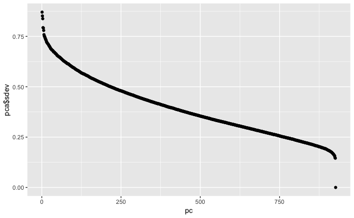

```r
pc <- 1:length(pca$sdev)
qplot(pc, pca$sdev)
```

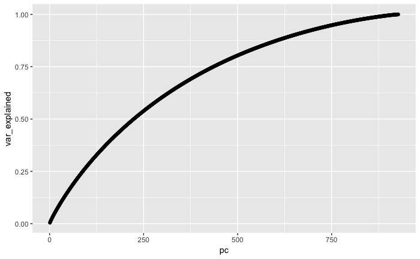

```r
var_explained <- cumsum(pca$sdev^2 / sum(pca$sdev^2))
qplot(pc, var_explained)
```

```r
s <- svd(y)
names(s)
```

```
[1] "d" "u" "v"
```

```r
y_svd <- s$u %*% diag(s$d) %*% t(s$v)
max(abs(y - y_svd))
```

```
[1] 7.389644e-13
```

```r
#Free memory
rm(pca,pcs,train_small,y)
rm(s,x,x2,y_svd)
```

```
object 'x' not foundobject 'x2' not found
```

```r
## recommenderlab package is good
```

```r
if(!require(randomForest)) install.packages("randomForest", repos = repo)
if(!require(inTrees)) install.packages("inTrees", repos = repo) #Used by rfRules model


#recipes package


## https://machinelearningmastery.com/tuning-machine-learning-models-using-the-caret-r-package/
##
## https://rpubs.com/chengjiun/52658

## https://machinelearningmastery.com/feature-selection-with-the-caret-r-package/

#cols

colNames <- names(myTrain)[1:7]
colNames[3] <- "rating"  #Remove titleId, and replace it with "rating"
colNames

names(myTrain[colNames])

# https://www.rdocumentation.org/packages/caret/versions/6.0-84/topics/train
# https://www.rdocumentation.org/packages/caret/versions/4.47/topics/train

# See list of models available in caret
names(getModelInfo())

# prepare training scheme  ##number and repeats set lower for faster executiion

#Alter myTrain to have fewer columns
myTrain <- myTrain[colNames]
trainControl <- trainControl(method="repeatedcv", number=5, repeats=2)

metric <- "RMSE"

# CART
set.seed(7)
fit.model1 <- train(rating ~ ., data =myTrain, method="rpart", metric = metric, maximize = FALSE,
    trControl=trainControl)

# Second Model
set.seed(7)
fit.model2 <- train(rating~., data=myTrain, method="rfRules", metric = metric, maximize = FALSE, na.action = na.omit,
                trControl=trainControl)
#fit.model2 <- train(rating~., data=myTrain, method="rf", metric = metric, maximize = FALSE,na.action = na.omit,
#               trControl=trainControl)

fit.model3 <- train(rating~., data=myTrain, method="rfRules", metric = metric, maximize = FALSE, na.action = na.omit,
                trControl=trainControl)

dart.parm <- list(booster = "dart", rate_drop = 0.1, nthread = 4, eta = 0.1, max_depth = 3, subsample = 1, eval_metric = "RMSE")
dart <- xgboost(data = myTrain, label = names(myTrain), params = dart.parm, nrounds = 500, verbose = 0, seed = 2017)
pred1 <- predict(dart, as.matrix(train[, -1]))
pred2 <- predict(dart, as.matrix(test[, -1]))
roc(as.factor(train$DEFAULT), pred1)
# Area under the curve: 0.7734
roc(as.factor(test$DEFAULT), pred2)
# Area under the curve: 0.6517

# collect resamples
results <- resamples(list(CART=fit.model1, RF=fit.model2))

# summarize differences between models
summary(results)

# box and whisker plots to compare models
scales <- list(x=list(relation="free"), y=list(relation="free"))
bwplot(results, scales=scales)

# dot plots of accuracy
scales <- list(x=list(relation="free"), y=list(relation="free"))
dotplot(results, scales=scales)

# pairwise scatter plots of predictions to compare models
splom(results)

# difference in model predictions
diffs <- diff(results)
# summarize p-values for pairwise comparisons
summary(diffs)
# Create a Random Forest model with default parameters
model1 <- randomForest(rating ~ ., data = myTrain[colNames], importance = TRUE, mtry=6)
model1
print(model1)

fit <- knn3(rating~., data=myTrain[colNames], k=3)
# summarize the fit
print(fit)
# make predictions
predictions <- predict(fit, df[,c(1,2,4,5,6)], type="class") # summarize accuracy
table(predictions, df$ratings)



# calculate correlation matrix
correlationMatrix <- cor(edx[,c(1,2,4,6)])
# summarize the correlation matrix
print(correlationMatrix)
# find attributes that are highly corrected (ideally >0.75)
highlyCorrelated <- findCorrelation(correlationMatrix, cutoff=0.5)
# print indexes of highly correlated attributes
print(highlyCorrelated)


## Try to reproduce the party::ctree result with trainning subsample

# ensure results are repeatable
set.seed(7)
# configure multicore
#library(doMC)
#registerDoMC(cores=4)
# load the library
#library(caret)
# load the dataset
data(iris)
# prepare training scheme
control <- trainControl(method="repeatedcv", number=40, repeats=10)
# train the model
model <- train(Species~., data=iris, method="lvq", trControl=control, tuneLength=10)
# summarize the model
print(model)


########################################
## Scratch Pad -- don't use code beyond here.
########################################

# GIVE UP ON USING pcaNNet, and use more conventional approaches like Random Forest.
# percent <- 0.005
# df<-getDf(percent)
# n<-length(df[,1])

# Put into a function so that I can easily re-run on smaller subsets until my code works well
# getYValues <- function(percent) {
#     res<-edx %>% select (rating)
#     rows <- length(res[,1])
#     n <- as.integer(rows * percent)
#     df <- res[[1:n]]
#     df
# }

# # Put into a function so that I can easily re-run on smaller subsets until my code works well
# getInputs <- function(percent){
#    res <- edx %>% select (-rating,-title)
#    rows <- length(res[,1])
#    n <- as.integer(rows * percent)
#    res[1:n,]
#
# }
# #xValues <- getInputs(percent)
# #yValues <- getYValues(percent)
# set.seed(1) # if using R 3.6.0: set.seed(1, sample.kind = "Rounding")
# subset <- createDataPartition(y = df$rating, times = 1, p = 0.1, list = FALSE)
# modelFit <- pcaNNet(rating ~ as.factor(userId) + as.factor(movieId), data=df,subset=subset,na.action=na.omit, weights = rep(1,n),thresh = rep(0.95,n),size=2)
# glimpse(modelFit)
# y_hat <- predict(modelFit,df)
#
#
#
#
# formula <- rating ~ userId + movieId + timestamp + title + genres
# fit.ctree <- train(formula, data=df,method='ctree',tuneGrid=expand.grid(mincriterion=0.95))
# ctreeVarImp = varImp(fit.ctree)
#
# ##ctree2 with CV
#   fitControl <- trainControl(method = 'cv', number=6,summaryFunction=defaultSummary)
#   set.seed(123)
#   Grid <- expand.grid(maxdepth = seq(15, 50,5))
#
#   formula <- rating ~ userId + movieId + timestamp + title + genres
#   fit.ctree2CV <- train(formula, data=df, method = 'ctree2', trControl=fitControl,tuneGrid=Grid,metric='RMSE')
```

The code below is a useful utility that shows you the objects in memory, and how large they are. Courtesy of stack overflow  
( https://stackoverflow.com/questions/1358003/tricks-to-manage-the-available-memory-in-an-r-session )

```r
# improved list of objects
.ls.objects <- function (pos = 1, pattern, order.by,
                        decreasing=FALSE, head=FALSE, n=5) {
    napply <- function(names, fn) sapply(names, function(x)
                                         fn(get(x, pos = pos)))
    names <- ls(pos = pos, pattern = pattern)
    obj.class <- napply(names, function(x) as.character(class(x))[1])
    obj.mode <- napply(names, mode)
    obj.type <- ifelse(is.na(obj.class), obj.mode, obj.class)
    obj.prettysize <- napply(names, function(x) {
                           format(utils::object.size(x), units = "auto") })
    obj.size <- napply(names, object.size)
    obj.dim <- t(napply(names, function(x)
                        as.numeric(dim(x))[1:2]))
    vec <- is.na(obj.dim)[, 1] & (obj.type != "function")
    obj.dim[vec, 1] <- napply(names, length)[vec]
    out <- data.frame(obj.type, obj.size, obj.prettysize, obj.dim)
    names(out) <- c("Type", "Size", "PrettySize", "Length/Rows", "Columns")
    if (!missing(order.by))
        out <- out[order(out[[order.by]], decreasing=decreasing), ]
    if (head)
        out <- head(out, n)
    out
}

# shorthand
lsos <- function(..., n=10) {
    .ls.objects(..., order.by="Size", decreasing=TRUE, head=TRUE, n=n)
}

lsos()
```

My notes:

Don’t use lm on huge datasets. Look at the alternatives using movie_avgs and user_avgs in the lectures.

34.7.5 Modeling movie effects

Don’t use lm_fit with huge amounts of data. Checkout 34.7.5 Modeling movie effects in EDXdatasciencebook.pdf for an alternative.

Use Genres to improve RMSE scores.

https://courses.edx.org/courses/course-v1:HarvardX+PH125.9x+2T2018/discussion/forum/1ae77f8b04e1c45e4b425cab952e4519ac2749f0/threads/5c7ac73b58adcb0994003491

R script = commented code Rmd = text + code + plots PDF = knit from Rmd

Test out tidyr::separate_rows(edx, genres, sep = “|”) on a very small subset of edx and see what it is doing..

================ So I just finished up the machine learning class and started this one. I started on my project and have calculated and used b_i and b_u to inform my prediction. I was expecting to have to do more, but by rmse is already below 8.7, which exceeds our target. Have I messed something up? Will I be punished for having code that doesn’t do everything the lessons did (regularization, genres, etc)?

Hi, You can try different methods and select one with the best performances with a reasonable explanation.

I just finished my analysis using the same two parameters, and was wondering if something was wrong as those two produce a reasonably good model per the rubric. I was going over the code time and again to make sure everything is right, and it appears to be. I am glad I am not the only one. For the record, I implemented regularization as well, but the improvement is not significant.

Don’t use lm on huge datasets. Look at the alternatives using movie_avgs and user_avgs in the lectures.

One tip from me is for the genre effect. It is important to note that each user has a different genre effect. Note also that each movie has different genres. Finally and most importantly, treat genres as independent. That is, if a movie is having Romance|Comedy, then treat it as having both romance and comedy rather than Romance|Comedy as one unit. This is due to sparseness of the data. If you treat each combination of the genre as unique then there will be many genres and very few ratings in each genre. This will not give you a robust estimate.

Using this it was possible for me to go below 0.85 RMSE.

I used most of the same methods. I personally could have spent more time on the regularization, but my first guess at lambda got me under the the required RMSE so I called it good. One of my reviewers called me on it saying It was dumb luck and i should have used cross validation (they were right) but they gave me full points.

Look at the rubric and see what you are being graded against. There isn’t a section for originality. So dont sweat it too much. Again save the fear for the choose your own project. I’m waiting on my staff review and its nerve racking.

[output not shown]

Don’t forget the github link: https://github.com/satyajitpatra1976/Capstone_PH125.9x

https://rafalab.github.io/dsbook/large-datasets.html#dimension-reduction

===========

Do a PCA to determie best predictors…

Check to see if they are correllated, and remove if they are.

Use multiple models, and see if results improve. Use an ensemble approach.

Tune parameters using cross-validation.

Use Regularization to limit effect of small data points

Use movie effect, user effect & genre effect to improve results.

Show plots to visualize results.